# Lab 7

Coleman Breen

November 08, 2018

# Instructions

**Exercises:** 1,4 (Pg. 358); 1,4 (Pgs. 371)

**Assigned:** Friday, November 2, 2018

**Due:** Friday, November 9, 2018 by 5:00 PM

**Submission:** Submit via an electronic document on Sakai. Must be submitted as a HTML file generated in RStudio. All assigned problems are chosen according to the textbook *R for Data Science*. You do not need R code to answer every question. If you answer without using R code, delete the code chunk. If the question requires R code, make sure you display R code. If the question requires a figure, make sure you display a figure. A lot of the questions can be answered in written response, but require R code and/or figures for understanding and explaining.

# Chapter 18 (Pg. 358)

## Exercise 1

Instead of using `lm()` to fit a straight line, you can use `loess()` to fit a smooth curve. Repeat the process of model fitting, grid generation, predictions, and visualization on sim1 using `loess()` instead of `lm()`. How does the result compare to `geom_smooth()`?

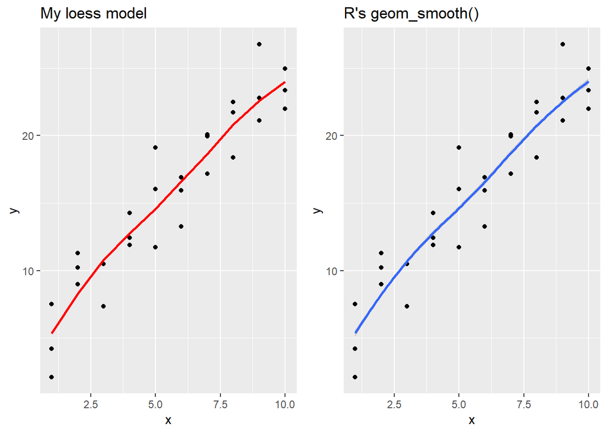

```r
#--> Load in data
data("sim1")

#--> Model fitting
sim1_loess <- loess(y ~ x, data = sim1)

#--> Grid generation
grid <- sim1 %>%
  data_grid(x)

#--> Add predictions to grid
grid <- grid %>%
  add_predictions(sim1_loess)

#--> Visualization
p1 <- ggplot(data = sim1, aes(x = x)) +
    geom_point(aes(y = y)) +
    geom_line(data = grid, aes(y = pred), color = "red", size = 1) +
    ggtitle("My loess model")

p2 <- ggplot(data = sim1, aes(x = x)) +
    geom_point(aes(y = y)) +
    geom_smooth(data = grid, aes(y = pred)) +
    ggtitle("R's geom_smooth()")

library(gridExtra)
grid.arrange(grobs = list(p1,p2), ncol = 2)
```

The two methods look nearly identical to me. There may be slight differences but to me, `geom_smooth()` and the model built on `loess()` are very similar.

## Exercise 4

Why might you want to look at a frequency polygon of absolute residuals? What are the pros and cons compared to looking at the raw residuals?

A frequency polygon is useful because it allows us to see the spread of residuals, rather than looking at raw numbers. Looking at the absolute residuals is also useful because it can tell us if there is a pattern at certain distances from the mean (0). Taking the absolute value simplifies the spread and can make those patterns easier to detect. For example, if the model over or underestimates by ~2, then we expect to see a spike at 2 when looking at the absolute values of residuals.

A drawback of using a frequency polygon of absolute residuals is that we lose information on the sign. We risk having a model that systematically over or underestimates the response variable.

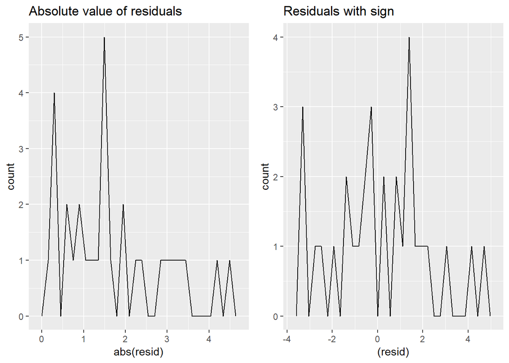

```r
#--> Fit residuals and plot
sim1 <- sim1 %>%
  add_residuals(sim1_loess)

p1 <- ggplot(sim1, aes(x = abs(resid))) +
  geom_freqpoly() +
  ggtitle("Absolute value of residuals")

p2 <- ggplot(sim1, aes(x = (resid))) +
  geom_freqpoly() +
  ggtitle("Residuals with sign")

grid.arrange(grobs = list(p1,p2), ncol = 2)
```

# Chapter 18 (Pg. 371)

## Exercise 1

What happens if you repeat the analysis of sim2 using a model without an intercept? What happens to the model equation? What happens to the predictions?

```r
#--> Load data
data("sim2")

#--> Model without intercept, drop 1s in the beginning
mod2.1 <- lm(y ~ x, data = sim2) #original
mod2.2 <- lm(y ~ x - 1, data = sim2) #no intercept

mod2.1
```

```
##
## Call:
## lm(formula = y ~ x, data = sim2)
##
## Coefficients:
## (Intercept)           xb           xc           xd
##      1.1522       6.9639       4.9750       0.7588
```

```r
mod2.2
```

```
##
## Call:
## lm(formula = y ~ x - 1, data = sim2)
##
## Coefficients:
##    xa     xb     xc     xd
## 1.152  8.116  6.127  1.911
```

```r
#--> Compare using grid
grid <- sim2 %>%
  data_grid(x) %>%
  spread_predictions(mod2.1, mod2.2)

grid
```

```
## # A tibble: 4 x 3
##   x     mod2.1 mod2.2
##   <chr>  <dbl>  <dbl>
## 1 a       1.15   1.15
## 2 b       8.12   8.12
## 3 c       6.13   6.13
## 4 d       1.91   1.91
```

## Exercise 4

For sim4, which of mod1 and mod2 is better? I think mod2 does a slightly better job at removing patterns, but it’s pretty subtle. Can you come up with a plot to support my claim?

The first round of plotting does not show much of a difference between mod1 and mod2. The mod2 model has a slightly lower standard deviation, which could hint at mod2 being subtly better than mod1.

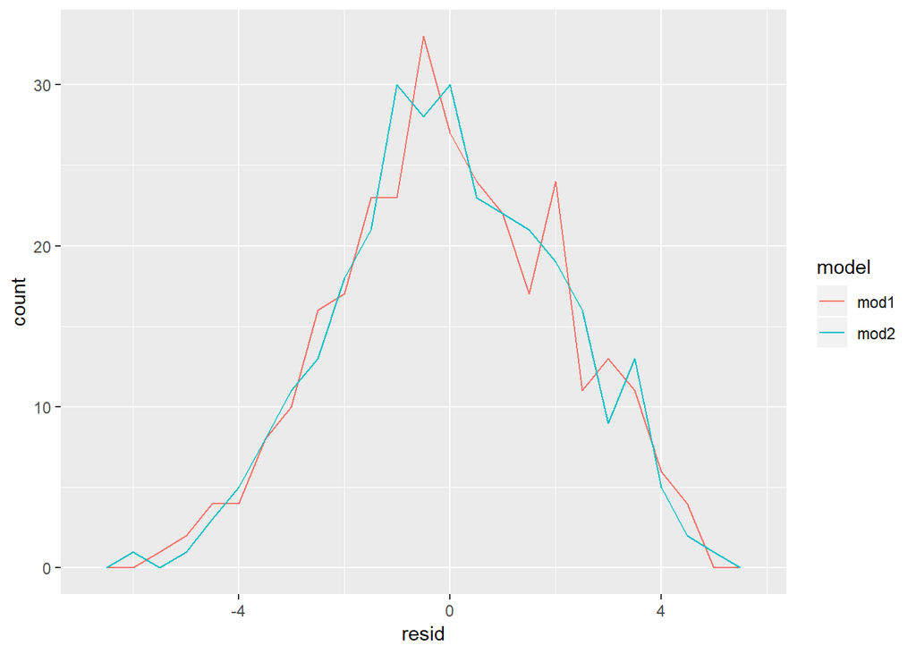

```r
#--> Load data
data("sim4")

#--> Fit models
mod1 <- lm(y ~ x1 + x2, data = sim4)
mod2 <- lm(y ~ x1 * x2, data = sim4)

#--> Add residuals
sim4_mods <- gather_residuals(sim4, mod1, mod2)

#--> Plot residuals
ggplot(sim4_mods, aes(x = resid, colour = model)) +
  geom_freqpoly(binwidth = 0.5) #standard in this chptr
```

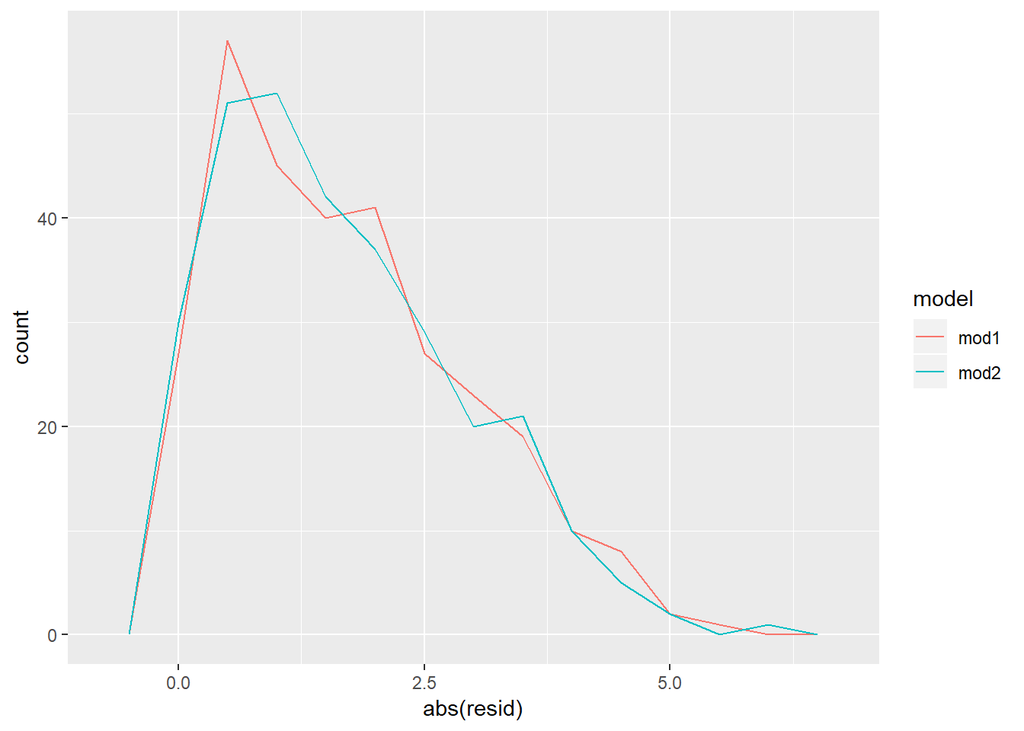

```r
#--> Plot absolute values
ggplot(sim4_mods, aes(x = abs(resid), colour = model)) +
  geom_freqpoly(binwidth = 0.5)
```

```r
#--> Look at standard deviation
sim4_mods %>%
  group_by(model) %>%
  summarise(resid = sd(resid))
```

```
## # A tibble: 2 x 2
##   model resid
##   <chr> <dbl>
## 1 mod1   2.10
## 2 mod2   2.07
```